[figure not shown]

CO(STI)-2

General Description

COOLING

1. General Description

A: SPECIFICATION

Cooling system

Electric fan + Forced engine coolant

circulation system

Total engine coolant capacity L (US qt, Imp qt) Approx. 7.7 (8.2, 6.8)

Water pump

Type Centrifugal impeller type

Discharge per-

formance

Discharge rate L (US gal, Imp gal)/min 200 (52.8, 44.0)

Pump speed — Discharge pressure 6,000 rpm — 225.4 kPa (23.0 mAq)

Engine coolant temperature 80°C (176°F)

Impeller diameter mm (in) 76 (2.99)

Number of impeller vanes 8

Pump pulley diameter mm (in) 60 (2.36)

Clearance between impeller and pump case mm (in) Standard 0.5 — 1.5 (0.020 — 0.059)

Thermostat

Type Wax pellet type

Starting temperature to open 76 — 80°C (169 — 176°F)

Fully opens 91°C (196°F)

Valve lift mm (in) 9.0 (0.354) or more

Valve opening size mm (in) 35 (1.38)

Radiator fan

Motor input

Main fan W 120

Sub fan W 120

Fan diameter /

Blade

Main fan 318.5 mm (12.54 in)/9

Sub fan 318.5 mm (12.54 in)/11

Radiator

Type Down flow

Core dimen-

sions

Width × Height × Thickness mm (in)

687.4 × 340 × 16

(27.06 × 13.39 × 0.63)

Pressure

range in which

cap valve is

open

Coolant filler

tank side

kPa (kg/cm

2

, psi)

Positive

pressure

side

Standard 93 — 123 (0.95 — 1.25, 14 — 18)

Limit 83 (0.85, 12)

Negative

pressure

side

Standard

–1.0 — –4.9

(–0.01 — –0.05, –0.1 — –0.7)

Radiator side kPa (kg/cm

2

, psi)

Positive

pressure

side only

Standard 122 — 152 (1.24 — 1.55, 18 — 22)

Limit 112 (1.14, 16)

Fins Corrugated fin type

Reservoir

tank

Capacity L (US qt, Imp qt) 0.45 (0.48, 0.40)

Recommended materials Item number Alternative

Coolant

SUBARU SUPER COOLANT

(concentrated type)

—

—

SUBARU SUPER COOLANT

(diluted type)

K0670Y0001

Water for dilution Distilled water — Soft water or tap water

Cooling system protective

agent

Cooling system conditioner SOA345001 —

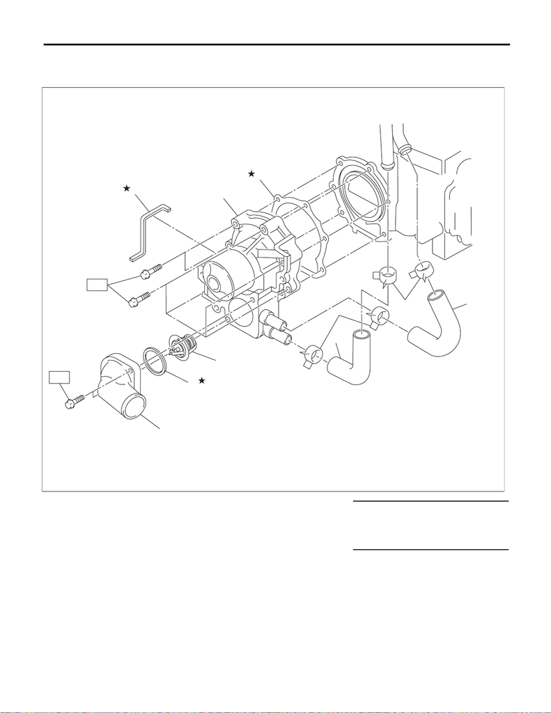

CO(STI)-3

General Description

COOLING

B: COMPONENT

1. WATER PUMP

(1) Water pump ASSY (6) Thermostat cover Tightening torque: N·m (kgf-m, ft-lb)

(2) Gasket (7) Coolant filler by-pass hose T1: First 12 (1.2, 8.9)

(3) Heater by-pass hose (8) Clip Second 12 (1.2, 8.9)

(4) Thermostat (9) Water pump sealing T2: 12 (1.2, 8.9)

(5) Gasket

CO-02779

(6)

(4)

(1)

(5)

(2)

T2

(3)

(7)

(8)

(8)

(9)

T1

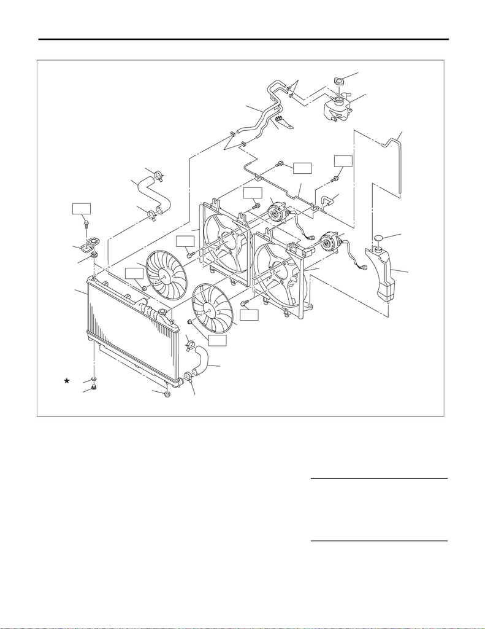

CO(STI)-4

General Description

COOLING

2. RADIATOR AND RADIATOR FAN

(1) Radiator lower cushion (12) Radiator main fan shroud (22) Over flow hose B

(2) Radiator (13) Radiator sub fan (23) Main fan motor

(3) Radiator upper cushion (14) Radiator main fan (24) Sub fan motor

(4) Radiator upper bracket (15) Radiator outlet hose (25) Clip

(5) Clip (16) Radiator drain plug

(6) Radiator inlet hose (17) O-ring Tightening torque: N·m (kgf-m, ft-lb)

(7) Engine coolant reservoir tank cap (18) Engine coolant filler tank T1: 3.4 (0.3, 2.5)

(8) Over flow hose A (19) Radiator cap (coolant filler tank

cap)

T2: 4.41 (0.45, 3.25)

(9) Engine coolant reservoir tank (20) Engine coolant hose A T3: 7.5 (0.8, 5.5)

(10) Over flow pipe (21) Engine coolant hose B T4: 12 (1.2, 8.9)

(11) Radiator sub fan shroud

(19)

(18)

(21)

(20)

CO-03378

(14)

T1

T3

T3

(9)

(7)

(10)

(8)

(23)

(25)

(25)

(24)

(12)

(11)

T2

T2

(5)

(6)

(5)

T3

(1)

(22)

(15)

(5)

(5)

(13)

T1

(2)

(16)

(17)

(3)

(4)

T4

[figure not shown]

CO(STI)-5

General Description

COOLING

C: CAUTION

• Prior to starting work, pay special attention to the following:

1. Always wear work clothes, a work cap, and protective shoes. Additionally, wear a helmet, protective

goggles, etc. if necessary.

2. Protect the vehicle using a seat cover, fender cover, etc.

3. Prepare the service tools, clean cloth, containers to catch grease and oil, etc.

• Prepare a container and cloth to prevent scattering of engine coolant when performing work where engine

coolant can be spilled. If the oil spills, wipe it off immediately to prevent from penetrating into floor or flowing

out for environmental protection.

• Vehicle components are extremely hot immediately after driving. Be wary of receiving burns from heated

parts.

• When performing a repair, identify the cause of trouble and avoid unnecessary removal, disassembly and

replacement.

• Before disconnecting connectors of sensors or units, be sure to disconnect the ground cable from battery.

• Always use the jack-up point when the shop jacks or rigid racks are used to support the vehicle.

• Remove contamination including dirt and corrosion before removal, installation, disassembly or assembly.

• Keep the removed parts in order and protect them from dust and dirt.

• All removed parts, if to be reused, should be reinstalled in the original positions with attention to the correct

directions, etc.

• Bolts, nuts and washers should be replaced with new parts as required.

• Be sure to tighten the fasteners including bolts and nuts to the specified torque.

• Follow all government and local regulations concerning disposal of refuse when disposing engine coolant.

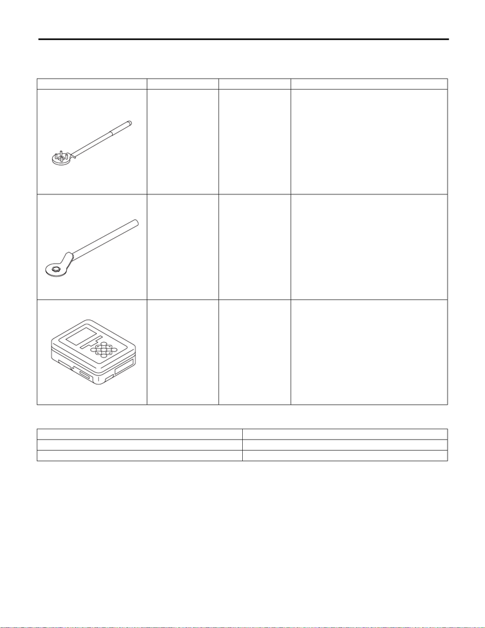

CO(STI)-6

General Description

COOLING

D: PREPARATION TOOL

1. SPECIAL TOOL

2. GENERAL TOOL

ILLUSTRATION TOOL NUMBER DESCRIPTION REMARKS

499977100 CRANK PULLEY

WRENCH

Used for removing and installing the crank pul-

ley.

499977500 CAM SPROCKET

WRENCH

Used for removing and installing intake cam

sprocket and exhaust cam sprocket.

1B022XU0 SUBARU SELECT

MONITOR III KIT

Used for troubleshooting the electrical system.

TOOL NAME REMARKS

Circuit tester Used for measuring resistance and voltage.

Radiator cap tester Used for checking radiator and radiator cap.

ST-499977100

ST-499977500

ST1B022XU0